# NeuronMotif Results

Latest update: 2022-09-17

This webpage is for showing more results of [NeuronMotif](https://doi.org/10.1101/2021.02.10.430606).

The code of NeuronMotif is available at github:

https://github.com/wzthu/NeuronMotif

If you have any questions about using NeuronMotif or downloading data, please feel free to contact:

*Zheng Wei*, weiz(at)tsinghua.edu.cn

Department of Automation, Tsinghua University

Cite: Wei, Zheng, et al. “NeuronMotif: Deciphering transcriptional cis-regulatory codes from deep neural networks.” bioRxiv (2021).[doi:10.1101/2021.02.10.430606](https://doi.org/10.1101/2021.02.10.430606)

# 1 The goal of NeuronMotif

NeuronMotif is an algorithm that can convert model weights of a well-trained Convolutional Neural Network (CNN) to motif grammar including motif dictionary and motif syntax (Figure I). NeuronMotif does not depend on any known positive sequence samples or other prior information. User only need to provide the architecture and the weight of CNN.

NeuronMotif Algorithm

- Input: convolutional neural network
- Output: cis-regulatory grammar (glossary and syntax)

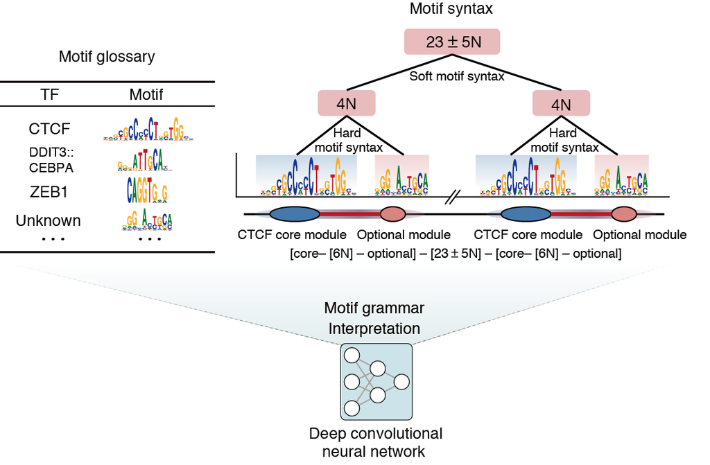

Figure I. The goal of NeuronMotif

# 2 Motif grammar examples

Trained by DeepSEA dataset:

- DeepSEA
- DD-10

Trained by Basset dataset:

- Basset
- BD-10

Here, we show some examples of the motifs decoupled from these models. See next section for details.

# 3 Motif grammar gallery

Download PPMs of CRMs and their visualization result for all convolutional neuron or footprinting result of layer-10 neuron in BD-10 and DD-10 model:

| Model | Dataset | PPM | Visualized result | Footprinting result |
| --- | --- | --- | --- | --- |
| DeepSEA | DeepSEA | [link](https://cloud.tsinghua.edu.cn/d/bee52a64d9e449c8897d/) | [link](https://cloud.tsinghua.edu.cn/d/f88d7b514fda47c4801a/) | NA |
| DD-10 | DeepSEA | [link](https://cloud.tsinghua.edu.cn/d/bee52a64d9e449c8897d/) | [link](https://cloud.tsinghua.edu.cn/d/56c58dd244a549ed8e3d/) | [link](https://cloud.tsinghua.edu.cn/f/5eb2c0d3c51140cb9d79/) |
| Basset | Basset | [link](https://cloud.tsinghua.edu.cn/d/bee52a64d9e449c8897d/) | [link](https://cloud.tsinghua.edu.cn/d/cbcf7006db1f4a27a222/) | NA |
| BD-10 | Basset | [link](https://cloud.tsinghua.edu.cn/d/bee52a64d9e449c8897d/) | [link](https://cloud.tsinghua.edu.cn/d/5b7cc143a18646b993f6/) | [link](https://cloud.tsinghua.edu.cn/f/3eb5250eea994552843f/) |

The files like xxx.tar.gz can be decompressed by `tar -xzvf xxx.tar.gz`

The subsections in this section show brief information and NeuronMotif visualization result of the 4 models.

## 3.1 DeepSEA Dataset

This dataset is obtained from the work:

Zhou, Jian, and Olga G. Troyanskaya. “Predicting effects of noncoding variants with deep learning–based sequence model.” Nature methods 12.10 (2015): 931-934.

Input is $1000\times4$ onehot code of DNA sequence.

Output is the boolen label of the DNA sequence to mark if it overlaps with 919 types of ChIP-seq (TF and HM) and DNase-seq peaks from different cell types.

### 3.1.1 DeepSEA model

Model structure is

```python
input_bp = 1000
conv_kernel_size = 8
pool_kernel_size = 4

maxnrom = MaxNorm(max_value=0.9, axis=0)
l1l2 = l1_l2(l1=0, l2=1e-6)

def crelu(x, alpha=0.0, max_value=None, threshold=1e-6):
    return relu(x, alpha, max_value, threshold)

batch_size=16

seqInput = Input(shape=(input_bp, 4), name='seqInput')

seq = Conv1D(320, conv_kernel_size,kernel_regularizer=l1l2, kernel_constraint=maxnrom)(seqInput)
seq = Activation(crelu)(seq)
seq = MaxPooling1D(pool_size=pool_kernel_size,strides=pool_kernel_size)(seq)
seq = Dropout(0.2)(seq)
seq = Conv1D(480, conv_kernel_size,kernel_regularizer=l1l2, kernel_constraint=maxnrom)(seq)
seq = Activation(crelu)(seq)
seq = MaxPooling1D(pool_size=pool_kernel_size,strides=pool_kernel_size)(seq)
seq = Dropout(0.2)(seq)
seq = Conv1D(960, conv_kernel_size,kernel_regularizer=l1l2, kernel_constraint=maxnrom)(seq)
seq = Activation(crelu)(seq)
seq = Dropout(0.5)(seq)
seq = Flatten()(seq)
seq = Dense(925,kernel_regularizer=l1l2, kernel_constraint=maxnrom)(seq)
seq = Activation(crelu)(seq)
seq = Dense(919,kernel_regularizer=l1l2, kernel_constraint=maxnrom, activity_regularizer=l1_l2(l1=1e-8,l2=0))(seq)
seq = Activation('sigmoid')(seq)

model = Model(inputs = [seqInput], outputs = [seq])
```

We applied NeuronMotif to this DCNN.

| Layer | Decouples | Neurons | CRMs | Links |
| --- | --- | --- | --- | --- |
| 1 | 1 | 320 | up to 1 PWMs/neuron | [link](http://bioinfo-xwwang-thu.cn/zwei/NeuronMotif/DeepSEA/layer1/index.html) |
| 2 | 1 | 480 | up to 4 PWMs/neuron | [link](http://bioinfo-xwwang-thu.cn/zwei/NeuronMotif/DeepSEA/layer2/index.html) |
| 3 | 1 | 960 | up to 16 PWMs/neuron | [link](http://bioinfo-xwwang-thu.cn/zwei/NeuronMotif/DeepSEA/layer3/index.html) |

### 3.1.2 DD-10 model

Model structure is

```python
input_bp=1000

seqInput = Input(shape=(input_bp, 4), name='seqInput')


seq = Conv1D(128, 7)(seqInput)
seq = BatchNormalization()(seq)
seq = Activation('relu')(seq)
seq = Conv1D(128, 3)(seq)
seq = BatchNormalization()(seq)
seq = Activation('relu')(seq)
seq = MaxPooling1D(2)(seq)
seq = Conv1D(160, 3)(seq)
seq = BatchNormalization()(seq)
seq = Activation('relu')(seq)
seq = Conv1D(160, 3)(seq)
seq = BatchNormalization()(seq)
seq = Activation('relu')(seq)
seq = MaxPooling1D(2)(seq)
seq = Conv1D(256, 3)(seq)
seq = BatchNormalization()(seq)
seq = Activation('relu')(seq)
seq = Conv1D(320, 3)(seq)
seq = BatchNormalization()(seq)
seq = Activation('relu')(seq)
seq = MaxPooling1D(2)(seq)
seq = Conv1D(512, 3)(seq)
seq = BatchNormalization()(seq)
seq = Activation('relu')(seq)
seq = Conv1D(640, 3)(seq)
seq = BatchNormalization()(seq)
seq = Activation('relu')(seq)
seq = MaxPooling1D(2)(seq)
seq = Conv1D(1024, 3)(seq)
seq = BatchNormalization()(seq)
seq = Activation('relu')(seq)
seq = Conv1D(1280, 3)(seq)
seq = BatchNormalization()(seq)
seq = Activation('relu')(seq)
seq = MaxPooling1D(2)(seq)
seq = Flatten()(seq)
seq = Dense(925)(seq)
seq = BatchNormalization()(seq)
seq = Activation('relu')(seq)
seq = Dropout(0.2)(seq)
seq = Dense(919)(seq)
seq = Activation('sigmoid')(seq)

model = Model(inputs = [seqInput], outputs = [seq])
```

We applied NeuronMotif to this DCNN.

[output not shown]

## 3.2 Basset Dataset

This dataset is obtained from the work:

Kelley, David R., Jasper Snoek, and John L. Rinn. “Basset: learning the regulatory code of the accessible genome with deep convolutional neural networks.” Genome research 26.7 (2016): 990-999.

Input is $600\times4$ onehot code of DNA sequence.

Output is the boolen label of the DNA sequence to mark if it overlaps with 164 types of DNase-seq peaks from different cell types.

### 3.2.1 Basset model

Model structure is

- Convolutional layer $kernel\_300 \times size\_19$
- Max-pooling layer $size\_3$
- Convolutional layer $kernel\_200 \times size\_11$
- Max-pooling layer $size\_4$
- Convolutional layer $kernel\_200 \times size\_7$
- Max-pooling layer $size\_4$

```python
input_bp = 600

seqInput = Input(shape=(input_bp, 4), name='seqInput')

seq = Conv1D(300, 19)(seqInput)
seq = BatchNormalization()(seq)
seq = Activation('relu')(seq)
seq = MaxPooling1D(pool_size=3)(seq)
seq = Conv1D(200, 11)(seq)
seq = BatchNormalization()(seq)
seq = Activation('relu')(seq)
seq = MaxPooling1D(pool_size=4)(seq)
seq = Conv1D(200, 7)(seq)
seq = BatchNormalization()(seq)
seq = Activation('relu')(seq)
seq = MaxPooling1D(pool_size=4)(seq)
seq = Flatten()(seq)
seq = Dense(1000)(seq)
seq = Activation('relu')(seq)
seq = Dropout(0.3)(seq)
seq = Dense(1000)(seq)
seq = Activation('relu')(seq)
seq = Dropout(0.3)(seq)
seq = Dense(164)(seq)
seq = Activation('sigmoid')(seq)


model = Model(inputs = [seqInput], outputs = [seq])
```

We applied NeuronMotif to this DCNN.

| Layer | Decouples | Neurons | CRMs | Links |
| --- | --- | --- | --- | --- |
| 1 | 1 | 300 | up to 1 PWMs/neuron | [link](http://bioinfo-xwwang-thu.cn/zwei/NeuronMotif/Basset/layer1/index.html) |
| 2 | 1 | 200 | up to 3 PWMs/neuron | [link](http://bioinfo-xwwang-thu.cn/zwei/NeuronMotif/Basset/layer2/index.html) |
| 3 | 1 | 200 | up to 12 PWMs/neuron | [link](http://bioinfo-xwwang-thu.cn/zwei/NeuronMotif/Basset/layer3/index.html) |

### 3.2.2 BD-10 model

Model structure is

- Convolutional layer $kernel\_64 \times size\_7$
- Convolutional layer $kernel\_64 \times size\_3$
- Max-pooling layer $size\_2$
- Convolutional layer $kernel\_128 \times size\_3$
- Convolutional layer $kernel\_128 \times size\_3$
- Max-pooling layer $size\_2$
- Convolutional layer $kernel\_256 \times size\_3$
- Convolutional layer $kernel\_256 \times size\_3$
- Max-pooling layer $size\_2$
- Convolutional layer $kernel\_384 \times size\_3$
- Convolutional layer $kernel\_384 \times size\_3$
- Max-pooling layer $size\_2$
- Convolutional layer $kernel\_512 \times size\_3$
- Convolutional layer $kernel\_512 \times size\_3$

```python
input_bp = 600


seqInput = Input(shape=(input_bp, 4), name='seqInput')

seq = Conv1D(64, 7)(seqInput)
seq = BatchNormalization()(seq)
seq = Activation('relu')(seq)
seq = Conv1D(64, 3)(seq)
seq = BatchNormalization()(seq)
seq = Activation('relu')(seq)
seq = MaxPooling1D(2)(seq)
seq = Conv1D(128, 3)(seq)
seq = BatchNormalization()(seq)
seq = Activation('relu')(seq)
seq = Conv1D(128, 3)(seq)
seq = BatchNormalization()(seq)
seq = Activation('relu')(seq)
seq = MaxPooling1D(2)(seq)
seq = Conv1D(256, 3)(seq)
seq = BatchNormalization()(seq)
seq = Activation('relu')(seq)
seq = Conv1D(256, 3)(seq)
seq = BatchNormalization()(seq)
seq = Activation('relu')(seq)
seq = MaxPooling1D(2)(seq)
seq = Conv1D(384, 3)(seq)
seq = BatchNormalization()(seq)
seq = Activation('relu')(seq)
seq = Conv1D(384, 3)(seq)
seq = BatchNormalization()(seq)
seq = Activation('relu')(seq)
seq = MaxPooling1D(2)(seq)
seq = Conv1D(512, 3)(seq)
seq = BatchNormalization()(seq)
seq = Activation('relu')(seq)
seq = Conv1D(512, 3)(seq)
seq = BatchNormalization()(seq)
seq = Activation('relu')(seq)
seq = Flatten()(seq)
seq = Dense(1024)(seq)
seq = BatchNormalization()(seq)
seq = Activation('relu')(seq)
seq = Dropout(0.2)(seq)
seq = Dense(164)(seq)
seq = Activation('sigmoid')(seq)

model = Model(inputs = [seqInput], outputs = [seq])
```

We applied NeuronMotif to this DCNN.

| Layer | Decouples | Neurons | CRMs | Links |
| --- | --- | --- | --- | --- |
| 1 | 1 | 64 | up to 1 PWMs/neuron | [link](http://bioinfo-xwwang-thu.cn/zwei/NeuronMotif/BD-10/layer1/index.html) |
| 2 | 1 | 64 | up to 1 PWMs/neuron | [link](http://bioinfo-xwwang-thu.cn/zwei/NeuronMotif/BD-10/layer2/index.html) |
| 3 | 1 | 128 | up to 2 PWMs/neuron | [link](http://bioinfo-xwwang-thu.cn/zwei/NeuronMotif/BD-10/layer3/index.html) |
| 4 | 1 | 128 | up to 2 PWMs/neuron | [link](http://bioinfo-xwwang-thu.cn/zwei/NeuronMotif/BD-10/layer4/index.html) |
| 5 | 1 | 256 | up to 4 PWMs/neuron | [link](http://bioinfo-xwwang-thu.cn/zwei/NeuronMotif/BD-10/layer5/index.html) |
| 6 | 1 | 256 | up to 4 PWMs/neuron | [link](http://bioinfo-xwwang-thu.cn/zwei/NeuronMotif/BD-10/layer6/index.html) |
| 7 | 1 | 384 | up to 8 PWMs/neuron | [link](http://bioinfo-xwwang-thu.cn/zwei/NeuronMotif/BD-10/layer7/index.html) |
| 8 | 1 | 384 | up to 8 PWMs/neuron | [link](http://bioinfo-xwwang-thu.cn/zwei/NeuronMotif/BD-10/layer8/index.html) |
| 9 | 1 | 512 | up to 16 PWMs/neuron | [link](http://bioinfo-xwwang-thu.cn/zwei/NeuronMotif/BD-10/layer9/index.html) |
| 10 | 2 | 512 | up to 256 PWMs/neuron | [link](http://bioinfo-xwwang-thu.cn/zwei/NeuronMotif/BD-10/layer10/index.html) |

# 4 References

[1] Zhou, Jian, and Olga G. Troyanskaya. “Predicting effects of noncoding variants with deep learning–based sequence model.” Nature methods 12.10 (2015): 931-934.

[2] Kelley, David R., Jasper Snoek, and John L. Rinn. “Basset: learning the regulatory code of the accessible genome with deep convolutional neural networks.” Genome research 26.7 (2016): 990-999.

[3] Shrikumar, Avanti, Peyton Greenside, and Anshul Kundaje. “Learning important features through propagating activation differences.” International Conference on Machine Learning. PMLR, 2017.

[4] Simonyan, Karen, Andrea Vedaldi, and Andrew Zisserman. “Deep inside convolutional networks: Visualising image classification models and saliency maps.” arXiv preprint arXiv:1312.6034 (2013).